```r
library(RcppRoll)
library(Rcpp)
library(readxl)
library(lubridate)
library(zoo)
library(ggplot2)
library(scales)
library(data.table)
library(corrplot)
library(ggcorrplot)
library(GGally)
library(forecast)
library(dplyr)
library(xts)
```

## Introduction

#### In this study, we are supposed to forecast UGS of the next four quarters of the given data. To do this, using regression methods are primary task.Our data contains many independent variables. Before forecasting, we first need to analyse data statiscally and build our model accordingly to forecast the sales.

### Data Manipulation and Initialization

```r
setwd('C:/Users/www')
hw2_data = read.csv("IE360_Spring22_HW2_data.csv", colClasses =c('character',rep('numeric',10)))
colnames(hw2_data) = c("Quarters", "UGS", "RNUV","NLPG","PU","PG","NUGV","NDGV","GNPA","GNPC","GNPT")
```

```r
hw2_data$Quarters = as.Date(as.yearqtr(hw2_data$Quarters,format = "%Y_Q%q"))
str(hw2_data)# structure is fine with all numerics.
hw2_original=hw2_data[c(1:28),]# split dataset into two, original set and test set with missing output values
hw2_test=hw2_data[c(29:32),]


hw2_original= data.table(hw2_original)
hw2_test= data.table(hw2_test)
```

```
'data.frame':	32 obs. of  11 variables:
 $ Quarters: Date, format: "2000-01-01" "2000-04-01" ...
 $ UGS     : num  1128971 1199569 1370167 1127548 1033918 ...
 $ RNUV    : num  0.0146 0.0205 0.0207 0.0163 0.0071 0.0051 0.0041 0.0048 0.0012 0.0032 ...
 $ NLPG    : num  940000 941000 943500 948000 950000 ...
 $ PU      : num  469 459 440 402 412 ...
 $ PG      : num  356 345 327 301 306 ...
 $ NUGV    : num  4647500 4742876 4840931 4919685 4954754 ...
 $ NDGV    : num  282 284 287 288 288 ...
 $ GNPA    : num  1040173 1760460 6974808 3267125 1004528 ...
 $ GNPC    : num  3483132 4525451 5915204 4929778 3418387 ...
 $ GNPT    : num  18022686 21797130 30050207 24480153 15832648 ...
```

## Visualisation of the data

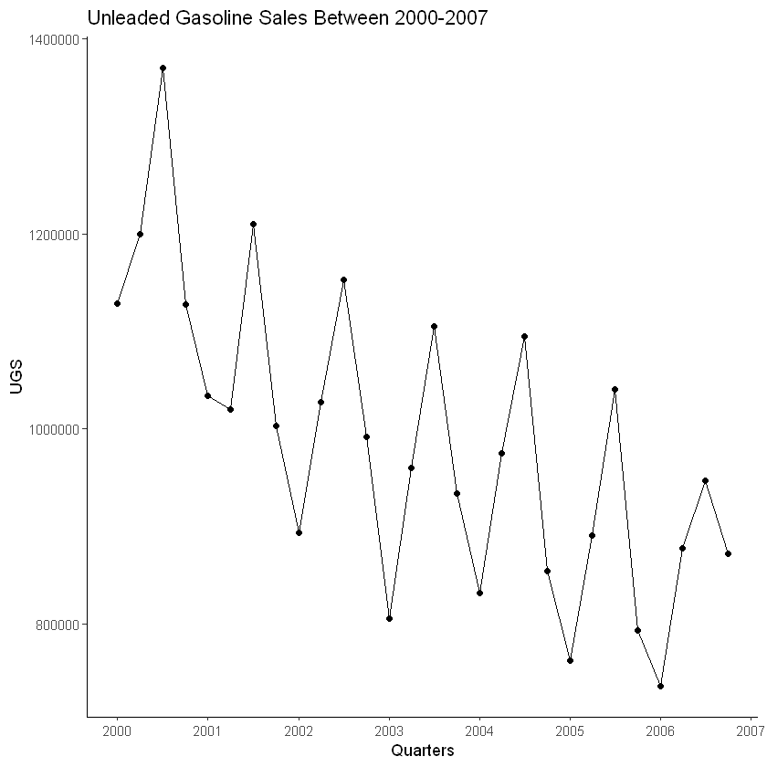

```r
ggplot(hw2_original, aes(x=Quarters,y=UGS))+geom_line()+geom_point()+
  labs(title = "Unleaded Gasoline Sales Between 2000-2007")+theme_classic()+scale_x_date(date_breaks = "1 year",
                                                                                         date_labels = "%Y")
```

### It is obvious that there is a declining trend behaviour. As for seasonality, in every 3rd quarter of the number of sales peeks. As this scenario occurs once in 4 quarters or yearly, it can be assumed that the data has yearly seasonality. Thus, as it is visually obvious, trend and seasonality are the principle components for the model.

```r
mean_ts=roll_mean(hw2_data$UGS[1:28],4,align='left')
var_ts=roll_var(hw2_data$UGS[1:28],4,align='left')
```

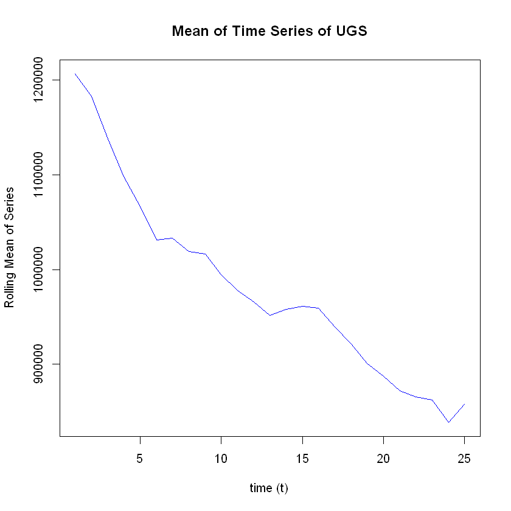

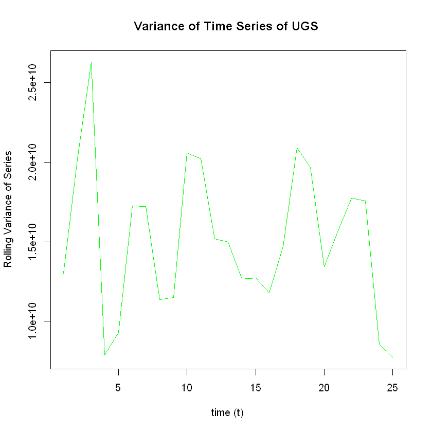

```r
plot(mean_ts, type='l',col='blue', xlab = "time (t)", ylab = "Rolling Mean of Series",main = "Mean of Time Series of UGS")
plot(var_ts,type='l',col='green',xlab = "time (t)",ylab = "Rolling Variance of Series",main = "Variance of Time Series of UGS ")
```

### There is a clear indication that the data is not stationary with respect to the mean. However, it seems that stationarity with respect to the variance holds when inspected with naked eyes.

## Autocorrelation function of UGS up to lag 14

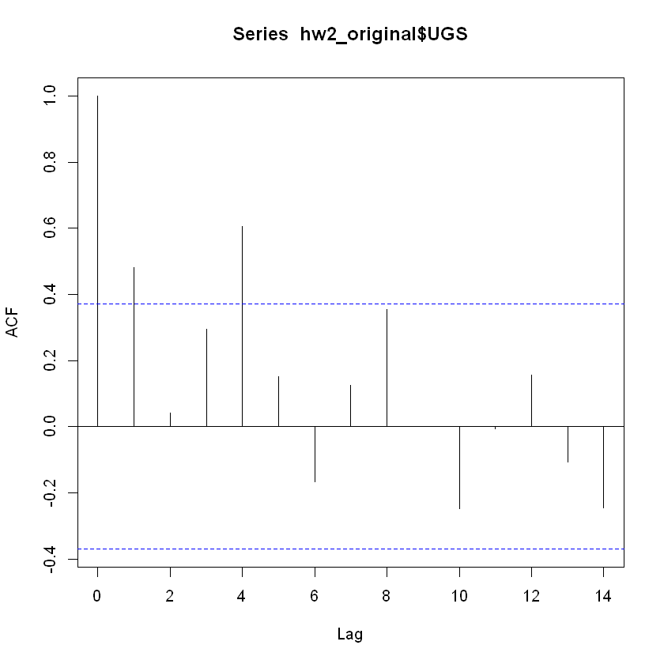

```r
acf(hw2_original$UGS)
```

```r
seasonality=seq(1,4,by=1) # this will be utilised as seasonality
hw2_original=cbind(hw2_original,seasonality)
```

### hw2_data$quareters will be used to explain the trend

## BUILDING THE MODEL

### Checking the correlations

### For better forecasting purposes, variables with significant with UGS will be considered to build the model.

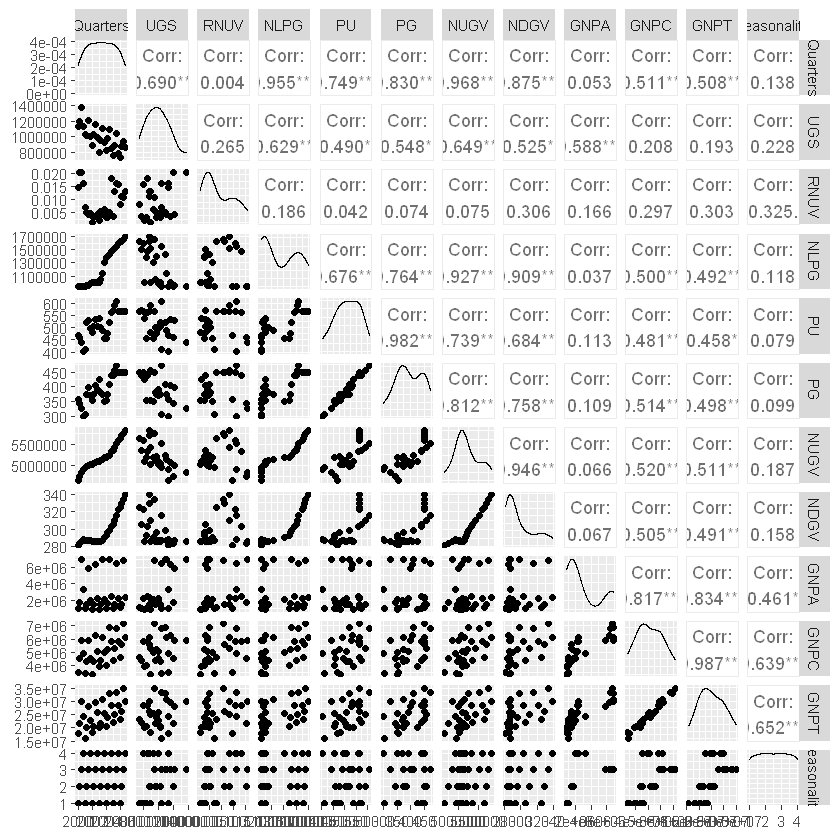

```r
ggpairs(hw2_original)
```

### As it is seen on the plot, the ones with asterikses are significant in explaining the target.

### Accordingly, GNPA, NDGV, NUGV, PG, PU, NLPG are the candidates to build the model.

### Quarters are also highly correlated,as trend component, it will be used in the model.

```
Call:
lm(formula = UGS ~ as.factor(seasonality) + Quarters, data = hw2_original)

Residuals:
   Min     1Q Median     3Q    Max
-81160 -31254  -3504  28684  94480

Coefficients:
                          Estimate Std. Error t value Pr(>|t|)
(Intercept)             2666578.76  152583.51  17.476 8.95e-15 ***
as.factor(seasonality)2  121380.99   25989.54   4.670 0.000106 ***
as.factor(seasonality)3  273421.28   26064.52  10.490 3.08e-10 ***
as.factor(seasonality)4   94953.53   26190.92   3.625 0.001419 **
Quarters                   -147.82      12.57 -11.762 3.29e-11 ***
---
Signif. codes:  0 '***' 0.001 '**' 0.01 '*' 0.05 '.' 0.1 ' ' 1

Residual standard error: 48580 on 23 degrees of freedom
Multiple R-squared:  0.9119,	Adjusted R-squared:  0.8966
F-statistic: 59.51 on 4 and 23 DF,  p-value: 8.468e-12
```

```
	Breusch-Godfrey test for serial correlation of order up to 8

data:  Residuals
LM test = 11.467, df = 8, p-value = 0.1766
```

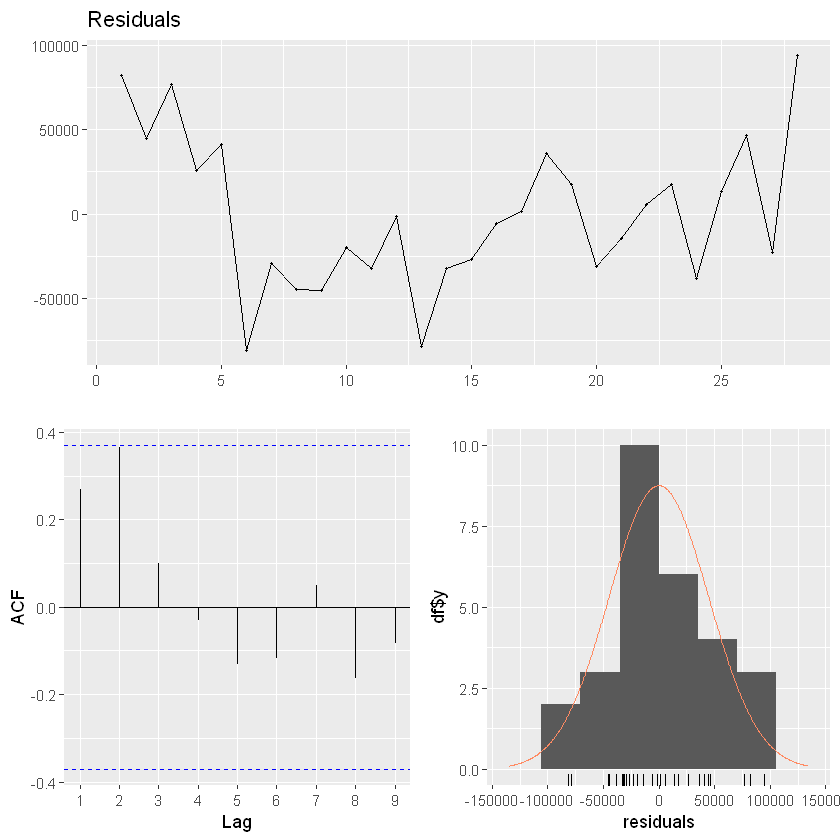

```r
### Start building with adding seasonality and trend

model0=lm(UGS~as.factor(seasonality)+Quarters, data=hw2_original)
summary(model0)
checkresiduals(model0)
```

#### As expected, seasonality and trend made a very good work in prediction. Corresponding t values for seasonality and trend are perfect. As for the model, it manifests promising in terms of r squared value and p-value. Additionally, shape of residuals quite resemble a normal distribution, however, we still somewhat worrying autocorrelations at lag 1 and 2. Lag1 and lag2 of some variables can be added to the model to overcome this.

#### Check cross-correlations of independent variables with residuals to see whether further improvements can be done on residuals hence, improvement in overall model and r squared.

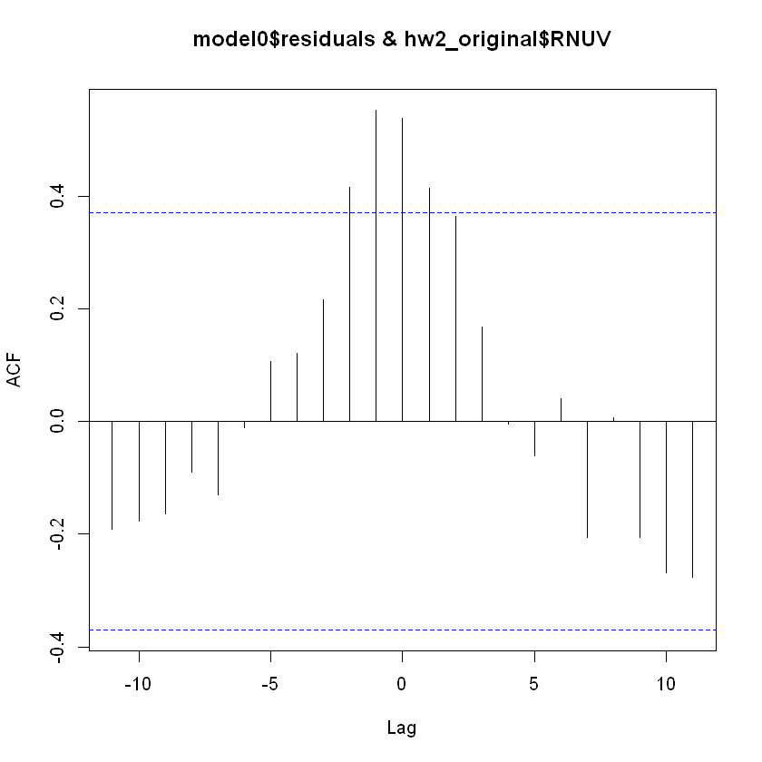

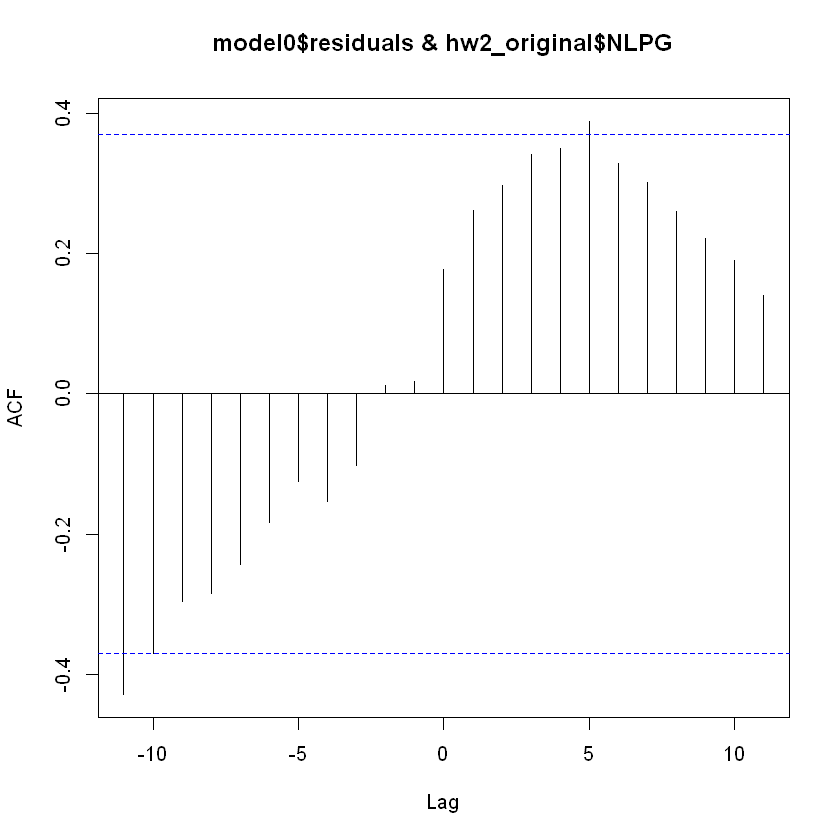

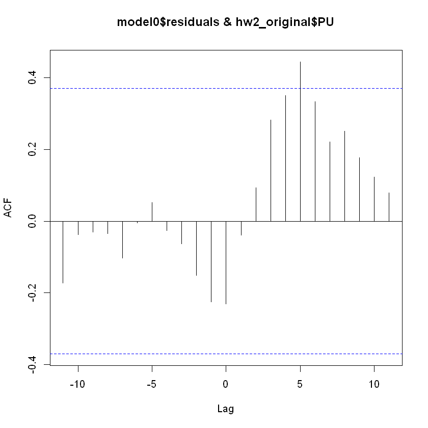

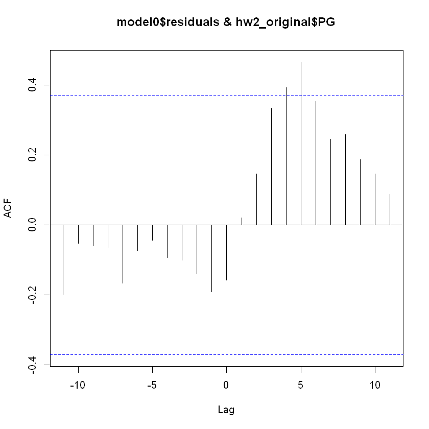

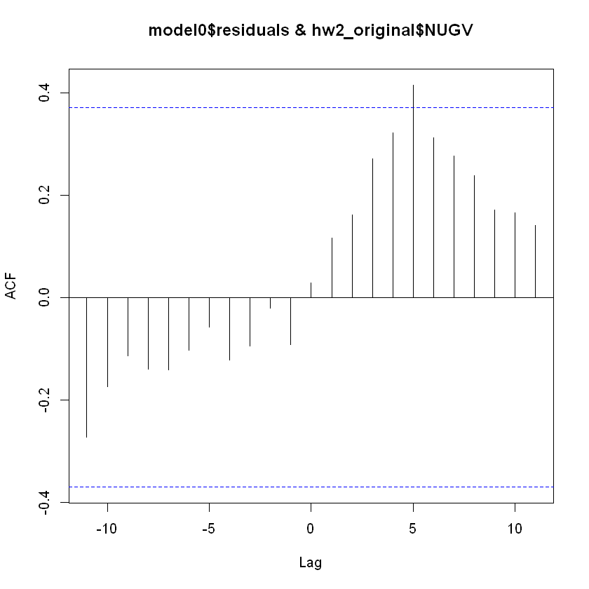

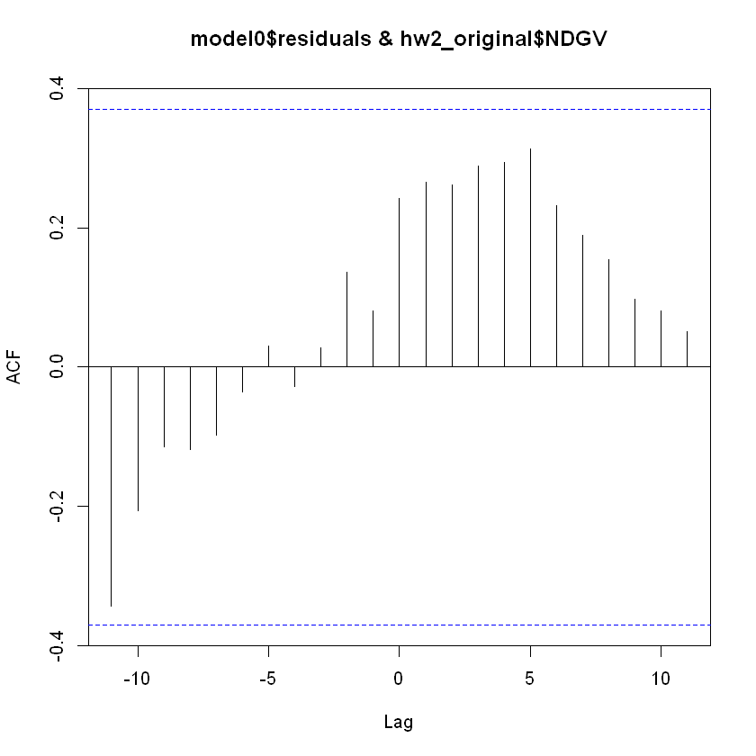

```r
ccf(model0$residuals,hw2_original$RNUV)
ccf(model0$residuals, hw2_original$NLPG)
ccf(model0$residuals, hw2_original$PU)
ccf(model0$residuals, hw2_original$PG)
ccf(model0$residuals, hw2_original$NUGV)
ccf(model0$residuals, hw2_original$NDGV)
```

```r
### lag 1 of RNUV seems  correlated with the current residuals let's add it to the model.
```

```r
hw2_original$RNUV_lag1=lag(hw2_original$RNUV,1)

model1=lm(UGS~as.factor(seasonality)+Quarters+RNUV_lag1, data=hw2_original)
summary(model1)
```

```
Call:
lm(formula = UGS ~ as.factor(seasonality) + Quarters + RNUV_lag1,
    data = hw2_original)

Residuals:
   Min     1Q Median     3Q    Max
-79547 -18352  -2994  25382  77648

Coefficients:
                          Estimate Std. Error t value Pr(>|t|)
(Intercept)             2491029.39  135430.82  18.393 1.99e-14 ***
as.factor(seasonality)2  155989.08   23306.36   6.693 1.27e-06 ***
as.factor(seasonality)3  294977.21   22311.66  13.221 1.20e-11 ***
as.factor(seasonality)4  114257.29   22270.42   5.130 4.41e-05 ***
Quarters                   -137.95      10.84 -12.728 2.44e-11 ***
RNUV_lag1               3764624.82 1346576.18   2.796   0.0108 *
---
Signif. codes:  0 '***' 0.001 '**' 0.01 '*' 0.05 '.' 0.1 ' ' 1

Residual standard error: 39780 on 21 degrees of freedom
  (1 observation deleted due to missingness)
Multiple R-squared:  0.9442,	Adjusted R-squared:  0.9309
F-statistic:    71 on 5 and 21 DF,  p-value: 1.953e-12
```

```
	Breusch-Godfrey test for serial correlation of order up to 9

data:  Residuals
LM test = 8.6006, df = 9, p-value = 0.4749
```

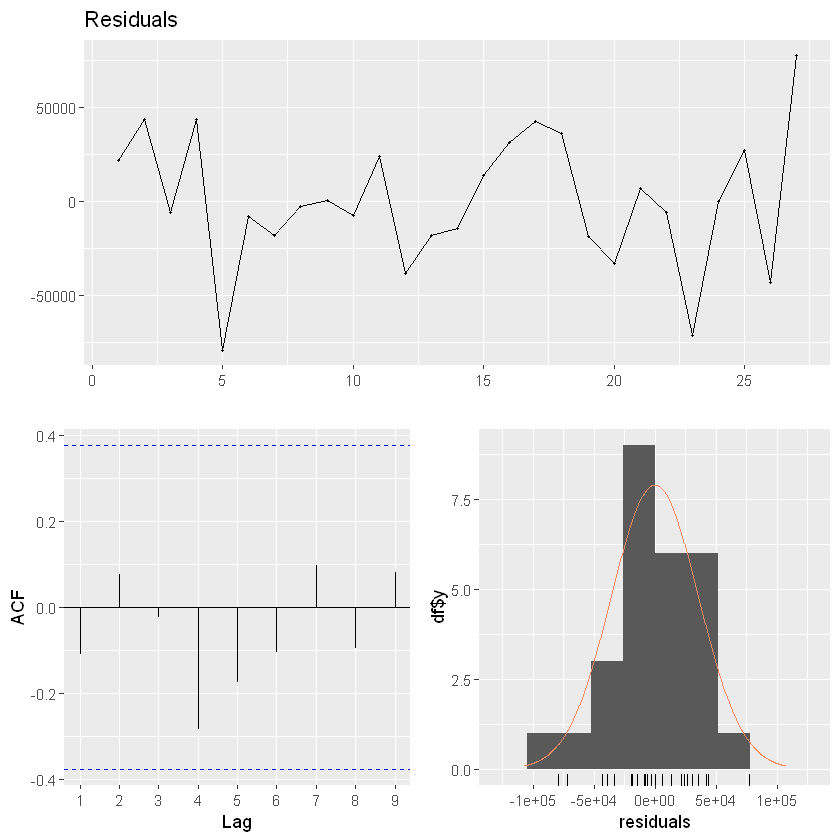

```r
checkresiduals(model1)
```

### When we look at the r squared value, the model seems very promising. As for other measures, there is no significant autocorrelation in the residuals and they form a shape like that of a normal distribution. Moreover, lastly added lagged variable is significant in the model.This model seems useful.

## Prediction

```r
hw2_test$RNUV_lag1[c(1:4)]=hw2_data$RNUV[c(28:31)]
prediction=predict(model1,hw2_test)
```

```r
# numerical results

prediction
```

**1**

676814.900539124

**2**

798177.007723266

**3**

936658.304157093

**4**

741364.482886219